# Mercedes Benz Greener Manufacturing

## Introduction

The first luxury car maker Benz Patented Motor Car in 1886, Mercedes-Benz has stood for important automotive innovations. These include, for example, the passenger safety cell with crumple zone, the airbag and intelligent assistance systems. Mercedes-Benz applies for nearly 2000 patents per year, making the brand the European leader among premium car makers. Daimler’s Mercedes-Benz cars are leaders in the premium car industry. With a huge selection of features and options, customers can choose the customized Mercedes-Benz of their dreams.

[figure not shown]

To ensure the safety and reliability of each and every unique car configuration before they hit the road, Daimler’s engineers have developed a robust testing system. But, optimizing the speed of their testing system for so many possible feature combinations is complex and time-consuming without a powerful algorithmic approach. As one of the world’s biggest manufacturers of premium cars, safety and efficiency are paramount on Daimler’s production lines.

## Overview

In an automobile industry, there is a testing department in which every vehicle that comes out from production manufacturing. Safety and reliable testing is a crucial part in the automobile manufacturing process. The Mercedes -Benz automobile industry every day manufactures a huge rate in producing vehicles and send to the testing department which is a final stage in production. Every possible vehicle combination must undergo a test bench to ensure the vehicle is robust enough to keep passengers safe and withstand in daily use. More tests result in more time spent on the test stand, increasing costs to the company and generating carbon dioxide, a polluting greenhouse gas.

[figure not shown]

## Aim

The main objective of this project is to optimize/reduce the testing time in process of every production vehicle that comes under the test bench. By this optimization it certainly decreases the Carbon dioxide emission associated with the testing procedure.

## Preliminary tasks

Let us now import the required libraries and datasets.

```python
!pip install xgboost
```

```python
#Load the libraries
import pandas as pd
import numpy as np
import matplotlib.pyplot as plt
import seaborn as sns
from sklearn.decomposition import PCA
import xgboost as xgb
from sklearn.metrics import r2_score
from sklearn.model_selection import train_test_split
%matplotlib inline
```

```python
#Load the data
train = pd.read_csv("C:/Users/ruben/OneDrive/Documents/Python_DS/Projects/Mercedes Benz Greener Manufacturing/train.csv")
test = pd.read_csv("C:/Users/ruben/OneDrive/Documents/Python_DS/Projects/Mercedes Benz Greener Manufacturing/test.csv")
```

```python
train.head(10) #Top 10 rows of train set
```

|  | ID | y | X0 | X1 | X2 | X3 | X4 | X5 | X6 | X8 | ... | X375 | X376 | X377 | X378 | X379 | X380 | X382 | X383 | X384 | X385 |
| --- | --- | --- | --- | --- | --- | --- | --- | --- | --- | --- | --- | --- | --- | --- | --- | --- | --- | --- | --- | --- | --- |
| 0 | 0 | 130.81 | k | v | at | a | d | u | j | o | ... | 0 | 0 | 1 | 0 | 0 | 0 | 0 | 0 | 0 | 0 |
| 1 | 6 | 88.53 | k | t | av | e | d | y | l | o | ... | 1 | 0 | 0 | 0 | 0 | 0 | 0 | 0 | 0 | 0 |
| 2 | 7 | 76.26 | az | w | n | c | d | x | j | x | ... | 0 | 0 | 0 | 0 | 0 | 0 | 1 | 0 | 0 | 0 |
| 3 | 9 | 80.62 | az | t | n | f | d | x | l | e | ... | 0 | 0 | 0 | 0 | 0 | 0 | 0 | 0 | 0 | 0 |
| 4 | 13 | 78.02 | az | v | n | f | d | h | d | n | ... | 0 | 0 | 0 | 0 | 0 | 0 | 0 | 0 | 0 | 0 |
| 5 | 18 | 92.93 | t | b | e | c | d | g | h | s | ... | 0 | 0 | 1 | 0 | 0 | 0 | 0 | 0 | 0 | 0 |
| 6 | 24 | 128.76 | al | r | e | f | d | f | h | s | ... | 0 | 0 | 0 | 0 | 0 | 0 | 0 | 0 | 0 | 0 |
| 7 | 25 | 91.91 | o | l | as | f | d | f | j | a | ... | 0 | 0 | 0 | 0 | 0 | 0 | 0 | 0 | 0 | 0 |
| 8 | 27 | 108.67 | w | s | as | e | d | f | i | h | ... | 1 | 0 | 0 | 0 | 0 | 0 | 0 | 0 | 0 | 0 |
| 9 | 30 | 126.99 | j | b | aq | c | d | f | a | e | ... | 0 | 0 | 1 | 0 | 0 | 0 | 0 | 0 | 0 | 0 |

10 rows × 378 columns

```python
train.shape
```

```
(4209, 378)
```

```python
test.head(10) #Top 10 rows of test set
```

|  | ID | X0 | X1 | X2 | X3 | X4 | X5 | X6 | X8 | X10 | ... | X375 | X376 | X377 | X378 | X379 | X380 | X382 | X383 | X384 | X385 |
| --- | --- | --- | --- | --- | --- | --- | --- | --- | --- | --- | --- | --- | --- | --- | --- | --- | --- | --- | --- | --- | --- |
| 0 | 1 | az | v | n | f | d | t | a | w | 0 | ... | 0 | 0 | 0 | 1 | 0 | 0 | 0 | 0 | 0 | 0 |
| 1 | 2 | t | b | ai | a | d | b | g | y | 0 | ... | 0 | 0 | 1 | 0 | 0 | 0 | 0 | 0 | 0 | 0 |
| 2 | 3 | az | v | as | f | d | a | j | j | 0 | ... | 0 | 0 | 0 | 1 | 0 | 0 | 0 | 0 | 0 | 0 |
| 3 | 4 | az | l | n | f | d | z | l | n | 0 | ... | 0 | 0 | 0 | 1 | 0 | 0 | 0 | 0 | 0 | 0 |
| 4 | 5 | w | s | as | c | d | y | i | m | 0 | ... | 1 | 0 | 0 | 0 | 0 | 0 | 0 | 0 | 0 | 0 |
| 5 | 8 | y | aa | ai | e | d | x | g | s | 0 | ... | 1 | 0 | 0 | 0 | 0 | 0 | 0 | 0 | 0 | 0 |
| 6 | 10 | x | b | ae | d | d | x | d | y | 0 | ... | 0 | 0 | 0 | 0 | 0 | 1 | 0 | 0 | 0 | 0 |
| 7 | 11 | f | s | ae | c | d | h | d | a | 0 | ... | 0 | 0 | 1 | 0 | 0 | 0 | 0 | 0 | 0 | 0 |
| 8 | 12 | ap | l | s | c | d | h | j | n | 0 | ... | 0 | 0 | 0 | 0 | 0 | 0 | 0 | 0 | 0 | 0 |
| 9 | 14 | o | v | as | f | d | g | f | v | 0 | ... | 0 | 0 | 0 | 0 | 0 | 0 | 0 | 0 | 0 | 0 |

10 rows × 377 columns

## Data Preparation

Let us prepare the data which is fit for modelling purposes. We need to ensure the data is indexed correctly, and that there is no missing values. Let us now check the statistical info of the dataset for more info

```python
train.describe()
```

|  | ID | y | X10 | X11 | X12 | X13 | X14 | X15 | X16 | X17 | ... | X375 | X376 | X377 | X378 | X379 | X380 | X382 | X383 | X384 | X385 |
| --- | --- | --- | --- | --- | --- | --- | --- | --- | --- | --- | --- | --- | --- | --- | --- | --- | --- | --- | --- | --- | --- |
| count | 4209.000000 | 4209.000000 | 4209.000000 | 4209.0 | 4209.000000 | 4209.000000 | 4209.000000 | 4209.000000 | 4209.000000 | 4209.000000 | ... | 4209.000000 | 4209.000000 | 4209.000000 | 4209.000000 | 4209.000000 | 4209.000000 | 4209.000000 | 4209.000000 | 4209.000000 | 4209.000000 |
| mean | 4205.960798 | 100.669318 | 0.013305 | 0.0 | 0.075077 | 0.057971 | 0.428130 | 0.000475 | 0.002613 | 0.007603 | ... | 0.318841 | 0.057258 | 0.314802 | 0.020670 | 0.009503 | 0.008078 | 0.007603 | 0.001663 | 0.000475 | 0.001426 |
| std | 2437.608688 | 12.679381 | 0.114590 | 0.0 | 0.263547 | 0.233716 | 0.494867 | 0.021796 | 0.051061 | 0.086872 | ... | 0.466082 | 0.232363 | 0.464492 | 0.142294 | 0.097033 | 0.089524 | 0.086872 | 0.040752 | 0.021796 | 0.037734 |
| min | 0.000000 | 72.110000 | 0.000000 | 0.0 | 0.000000 | 0.000000 | 0.000000 | 0.000000 | 0.000000 | 0.000000 | ... | 0.000000 | 0.000000 | 0.000000 | 0.000000 | 0.000000 | 0.000000 | 0.000000 | 0.000000 | 0.000000 | 0.000000 |
| 25% | 2095.000000 | 90.820000 | 0.000000 | 0.0 | 0.000000 | 0.000000 | 0.000000 | 0.000000 | 0.000000 | 0.000000 | ... | 0.000000 | 0.000000 | 0.000000 | 0.000000 | 0.000000 | 0.000000 | 0.000000 | 0.000000 | 0.000000 | 0.000000 |
| 50% | 4220.000000 | 99.150000 | 0.000000 | 0.0 | 0.000000 | 0.000000 | 0.000000 | 0.000000 | 0.000000 | 0.000000 | ... | 0.000000 | 0.000000 | 0.000000 | 0.000000 | 0.000000 | 0.000000 | 0.000000 | 0.000000 | 0.000000 | 0.000000 |
| 75% | 6314.000000 | 109.010000 | 0.000000 | 0.0 | 0.000000 | 0.000000 | 1.000000 | 0.000000 | 0.000000 | 0.000000 | ... | 1.000000 | 0.000000 | 1.000000 | 0.000000 | 0.000000 | 0.000000 | 0.000000 | 0.000000 | 0.000000 | 0.000000 |
| max | 8417.000000 | 265.320000 | 1.000000 | 0.0 | 1.000000 | 1.000000 | 1.000000 | 1.000000 | 1.000000 | 1.000000 | ... | 1.000000 | 1.000000 | 1.000000 | 1.000000 | 1.000000 | 1.000000 | 1.000000 | 1.000000 | 1.000000 | 1.000000 |

8 rows × 370 columns

```python
train.info() #Structure of the dataframe
```

```
<class 'pandas.core.frame.DataFrame'>
RangeIndex: 4209 entries, 0 to 4208
Columns: 378 entries, ID to X385
dtypes: float64(1), int64(369), object(8)
memory usage: 12.1+ MB
```

```python
#Finding the number of null values
print("Number of NaN values in train dataset is:",len(train[train.isna().any(axis=1)]))
print("Number of NaN values in test dataset is:",len(test[test.isna().any(axis=1)]))
```

```
Number of NaN values in train dataset is: 0
Number of NaN values in test dataset is: 0
```

```python
#Finding if there are any duplicates w.r.t ID column
print("Number of duplicated values in train dataset is:",train['ID'].duplicated().sum())
print("Number of duplicated values in test dataset is:",test['ID'].duplicated().sum())
```

```
Number of duplicated values in train dataset is: 0
Number of duplicated values in test dataset is: 0
```

```python
len(train.select_dtypes(include="int").columns) #number of Numerical columns
```

```
369
```

```python
len(train.select_dtypes(include="object").columns) #number of categorical columns
```

```
8
```

```python
train = train.drop('ID',axis =1)
```

```python
test = test.drop('ID',axis =1)
```

There are no missing data or duplicated data, hence we can proceeed further with the analysis on the 369 numerical columns and 8 columns.

## Exploratory Data Analysis (EDA)

The first step is to split the dataset into the feature and target dataframes. proceed with some visualizations to give some proper insight into the dataset.This provides a statistical characteristic and behavior of distribution of the data and also provide an insights in data.

```python
#Feature and target selection of variables
X_train = train.drop('y',axis=1)
y_train = train['y']
```

```python
X_train.head()
```

|  | X0 | X1 | X2 | X3 | X4 | X5 | X6 | X8 | X10 | X11 | ... | X375 | X376 | X377 | X378 | X379 | X380 | X382 | X383 | X384 | X385 |
| --- | --- | --- | --- | --- | --- | --- | --- | --- | --- | --- | --- | --- | --- | --- | --- | --- | --- | --- | --- | --- | --- |
| 0 | k | v | at | a | d | u | j | o | 0 | 0 | ... | 0 | 0 | 1 | 0 | 0 | 0 | 0 | 0 | 0 | 0 |
| 1 | k | t | av | e | d | y | l | o | 0 | 0 | ... | 1 | 0 | 0 | 0 | 0 | 0 | 0 | 0 | 0 | 0 |
| 2 | az | w | n | c | d | x | j | x | 0 | 0 | ... | 0 | 0 | 0 | 0 | 0 | 0 | 1 | 0 | 0 | 0 |
| 3 | az | t | n | f | d | x | l | e | 0 | 0 | ... | 0 | 0 | 0 | 0 | 0 | 0 | 0 | 0 | 0 | 0 |
| 4 | az | v | n | f | d | h | d | n | 0 | 0 | ... | 0 | 0 | 0 | 0 | 0 | 0 | 0 | 0 | 0 | 0 |

5 rows × 376 columns

```python
y_train.head()
```

```
0    130.81
1     88.53
2     76.26
3     80.62
4     78.02
Name: y, dtype: float64
```

### Analyzing and visualization of Categorical Variables

#### Bar plots for all the categorical variables

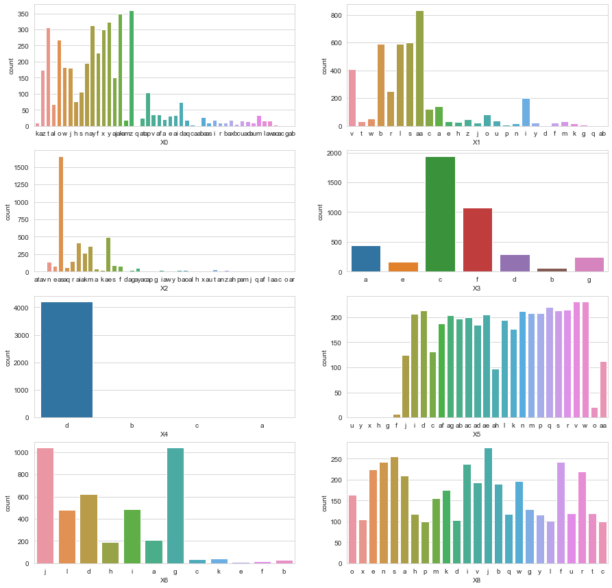

```python
#For all categorical feature
plt.figure(figsize = (15,15),)
sns.set_style('whitegrid')
for i in range(0,8):
    plt.subplot(4,2,i+1)
    sns.countplot(x=X_train.iloc[:,i], data=X_train)
plt.show()
```

From the above plot it can observe that X4 features have less variance in it.

#### Variation of different variables with time

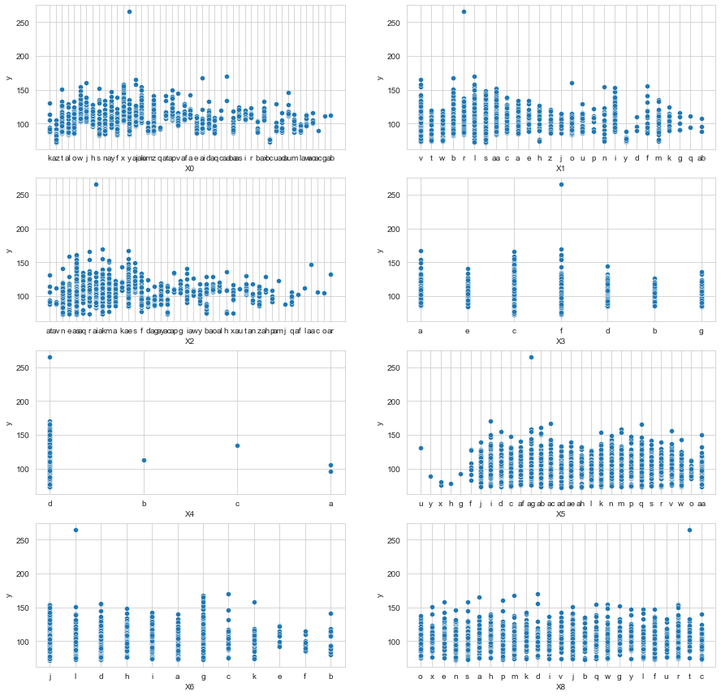

```python
plt.figure(figsize = (15,15),)
sns.set_style('whitegrid')
for i in range(0,8):
    plt.subplot(4,2,i+1)
    sns.scatterplot(x=X_train.iloc[:,i], y= y_train, data=X_train)
plt.show()
```

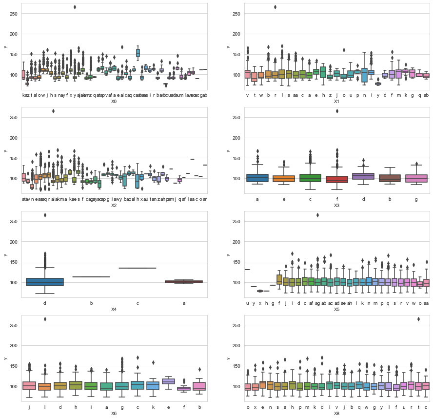

```python
plt.figure(figsize = (15,15),)
sns.set_style('whitegrid')
for i in range(0,8):
    plt.subplot(4,2,i+1)
    sns.boxplot(x=X_train.iloc[:,i], y= y_train, data=X_train)
plt.show()
```

## Data Preprocessing

```python
X_test = test.copy()
usable_columns = list(set(X_train.columns))
```

```python
test.head()
```

|  | X0 | X1 | X2 | X3 | X4 | X5 | X6 | X8 | X10 | X11 | ... | X375 | X376 | X377 | X378 | X379 | X380 | X382 | X383 | X384 | X385 |
| --- | --- | --- | --- | --- | --- | --- | --- | --- | --- | --- | --- | --- | --- | --- | --- | --- | --- | --- | --- | --- | --- |
| 0 | az | v | n | f | d | t | a | w | 0 | 0 | ... | 0 | 0 | 0 | 1 | 0 | 0 | 0 | 0 | 0 | 0 |
| 1 | t | b | ai | a | d | b | g | y | 0 | 0 | ... | 0 | 0 | 1 | 0 | 0 | 0 | 0 | 0 | 0 | 0 |
| 2 | az | v | as | f | d | a | j | j | 0 | 0 | ... | 0 | 0 | 0 | 1 | 0 | 0 | 0 | 0 | 0 | 0 |
| 3 | az | l | n | f | d | z | l | n | 0 | 0 | ... | 0 | 0 | 0 | 1 | 0 | 0 | 0 | 0 | 0 | 0 |
| 4 | w | s | as | c | d | y | i | m | 0 | 0 | ... | 1 | 0 | 0 | 0 | 0 | 0 | 0 | 0 | 0 | 0 |

5 rows × 376 columns

```python
#If for any column(s), the variance is equal to zero, then you need to remove those variable(s).
for col in usable_columns:
    cardinality = len(np.unique(X_train[col]))
    if cardinality == 1:
        X_train.drop(col, axis=1) # Column with only one, value is useless so we drop it
        X_test.drop(col, axis=1)
    if cardinality > 2: # Column is categorical
        mapper = lambda x: sum([ord(digit) for digit in x])
        X_train[col] = X_train[col].apply(mapper)
        X_test[col] = X_test[col].apply(mapper)
X_train.head()
```

|  | X0 | X1 | X2 | X3 | X4 | X5 | X6 | X8 | X10 | X11 | ... | X375 | X376 | X377 | X378 | X379 | X380 | X382 | X383 | X384 | X385 |
| --- | --- | --- | --- | --- | --- | --- | --- | --- | --- | --- | --- | --- | --- | --- | --- | --- | --- | --- | --- | --- | --- |
| 0 | 107 | 118 | 213 | 97 | 100 | 117 | 106 | 111 | 0 | 0 | ... | 0 | 0 | 1 | 0 | 0 | 0 | 0 | 0 | 0 | 0 |
| 1 | 107 | 116 | 215 | 101 | 100 | 121 | 108 | 111 | 0 | 0 | ... | 1 | 0 | 0 | 0 | 0 | 0 | 0 | 0 | 0 | 0 |
| 2 | 219 | 119 | 110 | 99 | 100 | 120 | 106 | 120 | 0 | 0 | ... | 0 | 0 | 0 | 0 | 0 | 0 | 1 | 0 | 0 | 0 |
| 3 | 219 | 116 | 110 | 102 | 100 | 120 | 108 | 101 | 0 | 0 | ... | 0 | 0 | 0 | 0 | 0 | 0 | 0 | 0 | 0 | 0 |
| 4 | 219 | 118 | 110 | 102 | 100 | 104 | 100 | 110 | 0 | 0 | ... | 0 | 0 | 0 | 0 | 0 | 0 | 0 | 0 | 0 | 0 |

5 rows × 376 columns

```python
test.head()
```

|  | X0 | X1 | X2 | X3 | X4 | X5 | X6 | X8 | X10 | X11 | ... | X375 | X376 | X377 | X378 | X379 | X380 | X382 | X383 | X384 | X385 |
| --- | --- | --- | --- | --- | --- | --- | --- | --- | --- | --- | --- | --- | --- | --- | --- | --- | --- | --- | --- | --- | --- |
| 0 | az | v | n | f | d | t | a | w | 0 | 0 | ... | 0 | 0 | 0 | 1 | 0 | 0 | 0 | 0 | 0 | 0 |
| 1 | t | b | ai | a | d | b | g | y | 0 | 0 | ... | 0 | 0 | 1 | 0 | 0 | 0 | 0 | 0 | 0 | 0 |
| 2 | az | v | as | f | d | a | j | j | 0 | 0 | ... | 0 | 0 | 0 | 1 | 0 | 0 | 0 | 0 | 0 | 0 |
| 3 | az | l | n | f | d | z | l | n | 0 | 0 | ... | 0 | 0 | 0 | 1 | 0 | 0 | 0 | 0 | 0 | 0 |
| 4 | w | s | as | c | d | y | i | m | 0 | 0 | ... | 1 | 0 | 0 | 0 | 0 | 0 | 0 | 0 | 0 | 0 |

5 rows × 376 columns

### Perform Principal Component Analysis (PCA)

Principal component analysis, or PCA, is a statistical procedure that allows you to summarize the information content in large data tables by means of a smaller set of “summary indices” that can be more easily visualized and analyzed. The goal is to extract the important information from the data and to express this information as a set of summary indices called **principal components** . Singular Value Decomposition or SVD is a computational method used to calculate principal components of a dataset. Linear dimensionality reduction using SVD of the data projects it to a lower dimensional space.

```python
#Dimensionality Reduction
n_comp = 12
pca = PCA(n_components=n_comp, random_state=420)
pca_train = pca.fit_transform(X_train)
pca_test = pca.transform(X_test)
```

```python
pca_train,pca_test
```

```
(array([[-49.08156207,  -4.90948084, -17.25085325, ...,   1.65808085,
           0.93316413,   1.67767261],
        [-48.94680383,  -7.22674339, -13.7631947 , ...,  -0.21429673,
           0.10928689,   0.44858868],
        [ 92.62761708,  31.9940341 , -26.17503456, ...,  -0.62195512,
           2.92579792,  -0.52629181],
        ...,
        [ 89.47970814,  20.44554421,  48.11999819, ...,  -1.27199613,
          -0.28730646,   2.00870035],
        [ 96.97110845,  31.50977186,  49.20059282, ...,   0.14362369,
          -0.98010171,   0.99232435],
        [-17.21024322, -14.22166025,  55.38091289, ...,  -0.28904254,
          -0.31644227,   0.6915868 ]]),
 array([[ 9.22615149e+01,  3.29260839e+01, -3.01130736e+01, ...,
         -4.11406384e-01,  3.62106392e+00, -1.20778172e+00],
        [-3.48622379e+01,  6.87132606e+00, -3.74760829e+01, ...,
          6.09253697e-01, -6.95870836e-01, -4.24945581e-01],
        [ 4.36560426e+01, -5.05939489e+01, -6.10591086e+01, ...,
         -3.20458181e-01,  2.60144802e+00, -1.53707632e+00],
        ...,
        [-2.52437784e+01, -2.63794193e+01,  5.40742341e+01, ...,
          6.03516083e-01,  2.60866858e-02,  3.68490704e-02],
        [ 4.53823778e+01, -6.38062446e+01,  3.58666036e+01, ...,
         -9.15187206e-01, -6.72291446e-01,  5.15293180e-01],
        [-4.23807477e+01, -2.52862351e+01,  6.10815522e+01, ...,
         -2.98836314e-01, -9.77070805e-01,  5.34362801e-02]]))
```

Now the data is ready for modelling purposes

## Data Modelling

Since there is already a test set, usually it isnt necessary to use the train test split for the dataset. However to improve model accuracy, it is better to have another test set from the train set i.e. validation set. This is helpful as this ensures a more accurate calculation of model performance.

```python
#Splitting the train test into Train and validation sets
X_train, X_valid, y_train, y_valid = train_test_split(pca_train, y_train, test_size=0.2, random_state=242)
```

Here we use xgboost regression which is boosting technique in ensemble to reduce bias while training the model.We begin by adding the datasets into the DMatrix or data matrix, which is an internal data structure that is used by XGBoost, which is optimized for both memory efficiency and training speed.

```python
#Creating D matrices
d_train = xgb.DMatrix(X_train, label=y_train)
d_valid = xgb.DMatrix(X_valid, label=y_valid)
#d_test = xgb.DMatrix(x_test)
d_test = xgb.DMatrix(pca_test)
```

```python
#Hyperparameters for the XGboost
params = {}
params['objective'] = 'reg:linear'
params['eta'] = 0.02
params['max_depth'] = 4
```

```python
#Defining the function to compute the R2 score
def xgb_r2_score(preds, dtrain):
    labels = dtrain.get_label()
    return 'r2', r2_score(labels, preds)
```

```python
#Creating the list of validation sets for which metrics will evaluated during training to track the model performance.
watchlist = [(d_train, 'train'), (d_valid, 'valid')]
```

```python
clf = xgb.train(params, d_train,
                1000, evals=watchlist, early_stopping_rounds=50,
                feval=xgb_r2_score, maximize=True, verbose_eval=10)
```

[output not shown]

```
[23:29:39] WARNING: C:/Users/Administrator/workspace/xgboost-win64_release_1.5.1/src/objective/regression_obj.cu:188: reg:linear is now deprecated in favor of reg:squarederror.
```

```python
#Predicting the time taken with respect to variables in the test set
predictions = clf.predict(d_test)
```

```python
test['Estimated Time'] = predictions
```

```python
test.head()
```

|  | X0 | X1 | X2 | X3 | X4 | X5 | X6 | X8 | X10 | X11 | ... | X376 | X377 | X378 | X379 | X380 | X382 | X383 | X384 | X385 | Estimated Time |
| --- | --- | --- | --- | --- | --- | --- | --- | --- | --- | --- | --- | --- | --- | --- | --- | --- | --- | --- | --- | --- | --- |
| 0 | az | v | n | f | d | t | a | w | 0 | 0 | ... | 0 | 0 | 1 | 0 | 0 | 0 | 0 | 0 | 0 | 79.836479 |
| 1 | t | b | ai | a | d | b | g | y | 0 | 0 | ... | 0 | 1 | 0 | 0 | 0 | 0 | 0 | 0 | 0 | 98.525581 |
| 2 | az | v | as | f | d | a | j | j | 0 | 0 | ... | 0 | 0 | 1 | 0 | 0 | 0 | 0 | 0 | 0 | 78.913269 |
| 3 | az | l | n | f | d | z | l | n | 0 | 0 | ... | 0 | 0 | 1 | 0 | 0 | 0 | 0 | 0 | 0 | 77.510704 |
| 4 | w | s | as | c | d | y | i | m | 0 | 0 | ... | 0 | 0 | 0 | 0 | 0 | 0 | 0 | 0 | 0 | 111.846794 |

5 rows × 377 columns